# MLAssignment2

## Assignment 2

#### Kevin Francis

Prepare/collect a hypothetical input-output (training) dataset for a supervised learning setup related to a classification problem. Based on the dataset, use any programming language to develop and perform a simulation study to classify the dataset applying any classification method. Explain the classification results with code and graphs.

Then, applying the KNN method, determine the class of a new testing data point. Explain the procedures with programming code and graphs. Change K values and explain how it impacts the speed and accuracy of the classification decisions for the new testing data point

```python
#Importing needed libraries
import numpy as np
import matplotlib.pyplot as plt
import pandas as pd
import seaborn as sns; sns.set(style = 'whitegrid')
from sklearn import svm, datasets
from sklearn.neighbors import KNeighborsClassifier as knn
import time
%matplotlib inline
```

I will start by generating some data to use, it will have two features and three classifications. The data will then be split 50/50 into a training and testing set. Below is also a scatter plot to look at all of the data at once.

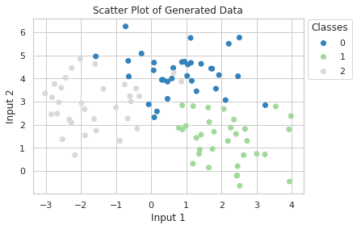

```python
# Generating grouped data
x, y = datasets.make_blobs(n_samples=100, centers=3, random_state=0, cluster_std=1.0)
# Splitting the training and testing data
half = int(len(x) / 2)
train_x = x[:half]
test_x = x[half:]
train_y = y[:half]
test_y = y[half:]
# Creating a scatter plot to look at all of the the initial data
fig, ax = plt.subplots()
scatter = ax.scatter(x[:, 0], x[:, 1], c = y, cmap = 'tab20c')
ax.set(xlabel='Input 1', ylabel='Input 2', title = 'Scatter Plot of Generated Data')
ax.legend(*scatter.legend_elements(), loc="lower left", title="Classes", bbox_to_anchor=(1, .63));
```

### Classification using a Support Vector Machine (SVM)

Now lets train a SVM model. This is done using scikit-learn, the default kernel is a Radial Basis Function (RBF). I decided to use the default RBF kernel based on the initial look of the data. The RBF is defined below:

$\phi(r) = e^{-(\gamma r)^2}$,

where $r = ||x-x'||$

```python
# Training the SVM model and looking at the accuracy on the test data
svm_model = svm.SVC(kernel = 'rbf')
svm_model.fit(train_x, train_y)
svm_model.score(test_x, test_y)
```

```
0.84
```

The accuracy of the SVM model on the test dataset is 84%

```python
# Plot was found on the scikitlearn documentation
# step size in the mesh
h = .02
# Plot the decision boundary. For that, we will assign a color to each
# point in the mesh [x_min, x_max] x [y_min, y_max].
x_min, x_max = x[:, 0].min() - 1, x[:, 0].max() + 1
y_min, y_max = x[:, 1].min() - 1, x[:, 1].max() + 1
xx, yy = np.meshgrid(np.arange(x_min, x_max, h), np.arange(y_min, y_max, h))
# Using the trained model to predict all of the points in the mesh
Z = svm_model.predict(np.c_[xx.ravel(), yy.ravel()])
Z = Z.reshape(xx.shape)
# Put the result into a color plot
```

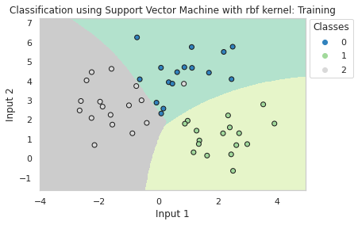

```python
fig, ax = plt.subplots()
ax.pcolormesh(xx, yy, Z, cmap = 'Pastel2', shading = 'auto')
# Plot the training data
scatter = ax.scatter(train_x[:, 0], train_x[:, 1], c = train_y, cmap = 'tab20c', edgecolors = 'k')
ax.set(xlabel='Input 1', ylabel='Input 2', title = 'Classification using Support Vector Machine with rbf kernel: Training')
ax.legend(*scatter.legend_elements(), loc = "lower left", title = "Classes", bbox_to_anchor = (1, .63));
```

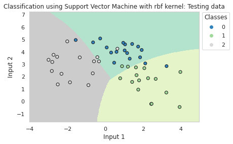

```python
fig, ax = plt.subplots()
ax.pcolormesh(xx, yy, Z, cmap='Pastel2', shading='auto')
# Plot the test data
scatter = ax.scatter(test_x[:, 0], test_x[:, 1], c = test_y, cmap = 'tab20c', edgecolors = 'k')
ax.set(xlabel = 'Input 1', ylabel = 'Input 2', title = 'Classification using Support Vector Machine with rbf kernel: Testing data')
ax.legend(*scatter.legend_elements(), loc = "lower left", title = "Classes", bbox_to_anchor = (1, .63));
```

### Classification using K Nearest Neighbors (KNN)

Now I will be using a K Nearest Neighbors model. I am using the same generated data from above, so that the accuracy from each model can be compared. For this I am using the brute force algorithm. This algorithm finds the distance for all pairs of points in the dataset. This can be computationally expensive, but since our dataset has 100 points and 50 for training and testing, I picked this method. I have each neighbor weighed uniformly for my data. This is because the data is domain agnostic and semi-random based on the standard deviation I define when creating the data. If there was some intuition or predictability to the data then having the weights assigned by distance might be better. This would assign a weight based on the inverse of the distance to the neighbor, so the closer a point the more influence it has.

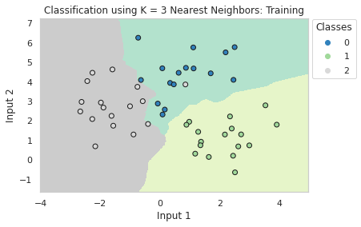

```python
# Initializing the model
kmodel = knn(n_neighbors = 3, algorithm = 'brute', weights = 'uniform')
# Training the model
kmodel.fit(train_x, train_y)
# step size in the mesh
h = .02
# Plot the decision boundary. For that, we will assign a color to each
# point in the mesh [x_min, x_max] x [y_min, y_max].
x_min, x_max = x[:, 0].min() - 1, x[:, 0].max() + 1
y_min, y_max = x[:, 1].min() - 1, x[:, 1].max() + 1
xx, yy = np.meshgrid(np.arange(x_min, x_max, h), np.arange(y_min, y_max, h))
Z = kmodel.predict(np.c_[xx.ravel(), yy.ravel()])
Z = Z.reshape(xx.shape)
fig, ax = plt.subplots()
ax.pcolormesh(xx, yy, Z, cmap = 'Pastel2', shading = 'auto')
# Plot the training data
scatter = ax.scatter(train_x[:, 0], train_x[:, 1], c = train_y, cmap = 'tab20c', edgecolors = 'k')
ax.set(xlabel = 'Input 1', ylabel = 'Input 2', title = 'Classification using K = 3 Nearest Neighbors: Training')
ax.legend(*scatter.legend_elements(), loc = "lower left", title = "Classes", bbox_to_anchor = (1, .63));
```

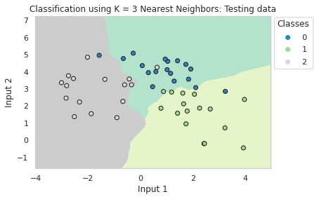

```python
# Plot the test data
fig, ax = plt.subplots()
ax.pcolormesh(xx, yy, Z, cmap = 'Pastel2', shading = 'auto')
scatter = ax.scatter(test_x[:, 0], test_x[:, 1], c = test_y, cmap = 'tab20c', edgecolors = 'k')
ax.set(xlabel = 'Input 1', ylabel = 'Input 2', title = 'Classification using K = 3 Nearest Neighbors: Testing data')
ax.legend(*scatter.legend_elements(), loc = "lower left", title = "Classes", bbox_to_anchor = (1, .63));
```

```python
# Accuracy of our trained model on the test dataset
kmodel.score(test_x, test_y)
```

```
0.92
```

It looks like for this dataset knn has achieved a better accuracy than the SVM. With k = 3 and uniform weights, the accuracy is 92%.

Now I will make up a data point and see if it is classified correctly.

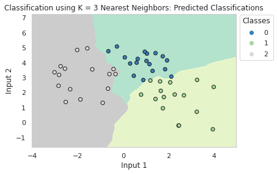

```python
# Plot the predicted data
pred_y = kmodel.predict(test_x)
fig, ax = plt.subplots()
ax.pcolormesh(xx, yy, Z, cmap = 'Pastel2', shading = 'auto')
scatter = ax.scatter(test_x[:, 0], test_x[:, 1], c = pred_y, cmap = 'tab20c', edgecolors = 'k')
ax.set(xlabel = 'Input 1', ylabel = 'Input 2', title = 'Classification using K = 3 Nearest Neighbors: Predicted Classifications')
ax.legend(*scatter.legend_elements(), loc = "lower left", title = "Classes", bbox_to_anchor = (1, .63));
```

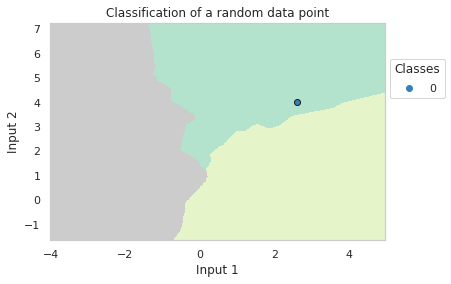

```python
# Random data point within the input bounds
test_point = np.array([[np.random.uniform(-4,4), np.random.uniform(-1,7)]])
#test_point = np.array([[-2, 3]])
# Predicting the class of the point
classification = kmodel.predict(test_point)
fig, ax = plt.subplots()
ax.pcolormesh(xx, yy, Z, cmap = 'Pastel2', shading = 'auto')
# Plot the training data
scatter = ax.scatter(test_point[:, 0], test_point[:, 1], c = classification, cmap = 'tab20c', edgecolors = 'k')
ax.set(xlabel = 'Input 1', ylabel = 'Input 2', title = 'Classification of a random data point')
ax.legend(*scatter.legend_elements(), loc = "lower left", title = "Classes", bbox_to_anchor = (1, .63));
```

As we can see, the point was classified correctly. However, it is important to note that not all random points will be classified correctly. Within the limited testing set we did not see 100% accuracy.

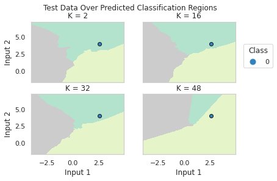

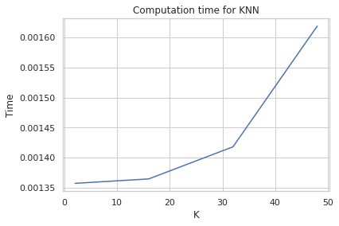

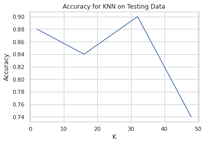

```python
# Lists to store the times and accuracies for each k value
times = []
acc = []
fig, ((ax1, ax2), (ax3, ax4)) = plt.subplots(2, 2)
ax = [ax1, ax2, ax3, ax4]
h = .02
x_min, x_max = x[:, 0].min() - 1, x[:, 0].max() + 1
y_min, y_max = x[:, 1].min() - 1, x[:, 1].max() + 1
xx, yy = np.meshgrid(np.arange(x_min, x_max, h), np.arange(y_min, y_max, h))
for k, i in enumerate([2, 16, 32, 48]):
    kmodel = knn(n_neighbors = i, algorithm = 'brute', weights = 'uniform')
    kmodel.fit(train_x, train_y)
    start = time.time()
    pred_y = kmodel.predict(test_x)
    finish = time.time()
    times.append(finish - start)
    acc.append(kmodel.score(test_x, test_y))
    Z = kmodel.predict(np.c_[xx.ravel(), yy.ravel()])
    Z = Z.reshape(xx.shape)
    ax[k].pcolormesh(xx, yy, Z, cmap = 'Pastel2', shading = 'auto')
    ax[k].set(xlabel = 'Input 1', ylabel = 'Input 2', title = 'K = ' + str(i))
    ax[k].label_outer()
    ax[k].scatter(test_point[:, 0], test_point[:, 1], c=classification, cmap = 'tab20c', edgecolors = 'k');
ax[2].legend(*scatter.legend_elements(), loc = "lower left", title = "Class", bbox_to_anchor = (2.25, 1.38), markerscale = 1.5);
fig.suptitle('Test Data Over Predicted Classification Regions')
plt.show()
plt.plot([2, 16, 32, 48], times)
plt.xlabel('K')
plt.ylabel('Time')
plt.title('Computation time for KNN')
plt.show()
plt.plot([2, 16, 32, 48], acc)
plt.xlabel('K')
plt.ylabel('Accuracy')
plt.title('Accuracy for KNN on Testing Data')
plt.show()
```

### Results

Without much tuning of any hyperparameters, the KNN model was a little more accurate than the SVM model with k = 3. However, you can see from the last part that k plays a very important role. The accuracy was as low as 74% with k = 48. Although that is extreme since the training set only has 50 data points, it is useful to show the relationships here. This can also be seen by the random test point, when k = 48 it is not classified correctly. Also a k increases so does the computation time. Note that for not large increases in k, such as 2 and 4, the difference in time has a large variance. Sometimes k = 4 might run faster. This is based on me doing about 100 runs and the plot never looking consistent until largely increasing k.

To conclude, I think both models performed well with this dataset. The accuracy might be able to be improved with some hyperparameter tuning or different kernels for the SVM model. An interesting follow-on would be to see how these exact models perform on different data sets.